# Lab6

Elke Windschitl

2023-03-01

```r
library(readr)
library(tidyverse)
library(tidymodels)
library(xgboost)
library(tictoc)
library(vip)
library(rsample)
library(recipes)
library(pROC)
```

## Case Study Eel Species Distribution Modeling

This week’s lab follows a modeling project described by Elith et al. (2008) (Supplementary Reading)

## Data

Grab the model training data set from the class Git:

data/eel.model.data.csv

```r
urlfile <- "https://raw.githubusercontent.com/MaRo406/eds-232-machine-learning/main/data/eel.model.data.csv"

eel_data <- read_csv(url(urlfile)) %>%
  select(-Site)
eel_data$Angaus <- as.factor(eel_data$Angaus)
```

### Split and Resample

Split the joined data from above into a training and test set, stratified by outcome score. Use 10-fold CV to resample the training set, stratified by Angaus

```r
# Stratified sampling with the rsample package
set.seed(123) #set a seed for reproducibility
split <- initial_split(data = eel_data,
                       prop = .7,
                       strata = "Angaus")
split
```

```
## <Training/Testing/Total>
## <699/301/1000>
```

```r
eel_train <- training(split)
eel_test  <- testing(split)

# Set up cross validation
cv_folds <- eel_train %>%
  vfold_cv(v=10, strata = "Angaus")
```

### Preprocess

Create a recipe to prepare your data for the XGBoost model. We are interested in predicting the binary outcome variable Angaus which indicates presence or absence of the eel species Anguilla australis

```r
eel_rec <- recipe(Angaus ~ ., data = eel_train) %>%
  step_dummy(all_nominal(), -all_outcomes(), one_hot = TRUE) %>%
  prep(training = eel_train, retain = TRUE)

# bake to check
baked_eel <- bake(eel_rec, eel_train)
```

## Tuning XGBoost

### Tune Learning Rate

Following the XGBoost tuning strategy outlined on Monday, first we conduct tuning on just the learn_rate parameter:

1. Create a model specification using {xgboost} for the estimation
- Only specify one parameter to tune()

```r
eel_spec <- parsnip::boost_tree(mode = "classification",
                                engine = "xgboost",
                                trees = 3000,
                                learn_rate = tune())
```

2. Set up a grid to tune your model by using a range of learning rate parameter values: expand.grid(learn_rate = seq(0.0001, 0.3, length.out = 30))
- Use appropriate metrics argument(s) - Computational efficiency becomes a factor as models get more complex and data get larger. Record the time it takes to run. Do this for each tuning phase you run.You could use {tictoc} or Sys.time().

```r
tic()
eel_grid <- expand.grid(learn_rate = seq(0.0001, 0.3, length.out = 30))
eel_grid
```

```
##    learn_rate
## 1  0.00010000
## 2  0.01044138
## 3  0.02078276
## 4  0.03112414
## 5  0.04146552
## 6  0.05180690
## 7  0.06214828
## 8  0.07248966
## 9  0.08283103
## 10 0.09317241
## 11 0.10351379
## 12 0.11385517
## 13 0.12419655
## 14 0.13453793
```

[output cut: 16 more lines]

```r
wf_eel_tune <- workflow() %>%
  add_recipe(eel_rec) %>%
  add_model(eel_spec)
toc()
```

```
## 0.008 sec elapsed
```

```r
tic()
doParallel::registerDoParallel()

set.seed(123)

eel_rs <- tune_grid(
  wf_eel_tune,
  Angaus~.,
  resamples = cv_folds,
  grid = eel_grid
 # metrics = metric_set(accuracy, roc_auc) -- this wasn't working when I did this
)
toc()
```

```
## 136.053 sec elapsed
```

```r
eel_rs
```

```
## # Tuning results
## # 10-fold cross-validation using stratification
## # A tibble: 10 × 4
##    splits           id     .metrics          .notes
##    <list>           <chr>  <list>            <list>
##  1 <split [628/71]> Fold01 <tibble [60 × 5]> <tibble [0 × 3]>
##  2 <split [629/70]> Fold02 <tibble [60 × 5]> <tibble [0 × 3]>
##  3 <split [629/70]> Fold03 <tibble [60 × 5]> <tibble [0 × 3]>
##  4 <split [629/70]> Fold04 <tibble [60 × 5]> <tibble [0 × 3]>
##  5 <split [629/70]> Fold05 <tibble [60 × 5]> <tibble [0 × 3]>
##  6 <split [629/70]> Fold06 <tibble [60 × 5]> <tibble [0 × 3]>
##  7 <split [629/70]> Fold07 <tibble [60 × 5]> <tibble [0 × 3]>
##  8 <split [629/70]> Fold08 <tibble [60 × 5]> <tibble [0 × 3]>
##  9 <split [630/69]> Fold09 <tibble [60 × 5]> <tibble [0 × 3]>
## 10 <split [630/69]> Fold10 <tibble [60 × 5]> <tibble [0 × 3]>
```

3. Show the performance of the best models and the estimates for the learning rate parameter values associated with each.

```r
eel_rs %>%
  tune::show_best(metric = "accuracy") %>%
  knitr::kable()
```

| learn_rate | .metric | .estimator | mean | n | std_err | .config |
| --- | --- | --- | --- | --- | --- | --- |
| 0.1655621 | accuracy | binary | 0.8312548 | 10 | 0.0102540 | Preprocessor1_Model17 |
| 0.1035138 | accuracy | binary | 0.8312352 | 10 | 0.0091530 | Preprocessor1_Model11 |
| 0.3000000 | accuracy | binary | 0.8298469 | 10 | 0.0129247 | Preprocessor1_Model30 |
| 0.1448793 | accuracy | binary | 0.8298256 | 10 | 0.0110078 | Preprocessor1_Model15 |
| 0.2379517 | accuracy | binary | 0.8298061 | 10 | 0.0110902 | Preprocessor1_Model24 |

```r
eel_best_learn <- eel_rs %>%
  tune::select_best("accuracy")

knitr::kable(eel_best_learn)
```

| learn_rate | .config |
| --- | --- |
| 0.1655621 | Preprocessor1_Model17 |

```r
eel_model <- eel_spec %>%
  finalize_model(eel_best_learn)
```

### Tune Tree Parameters

1. Create a new specification where you set the learning rate (which you already optimized) and tune the tree parameters.

```r
eel_spec2 <- parsnip::boost_tree(mode = "classification",
                                engine = "xgboost",
                                trees = 3000,
                                learn_rate = eel_best_learn$learn_rate,
                                min_n = tune(),
                                tree_depth = tune(),
                                loss_reduction = tune()
                                )
```

2. Set up a tuning grid. This time use grid_max_entropy() to get a representative sampling of the parameter space

```r
eel_params <- dials::parameters(
  min_n(),
  tree_depth(),
  loss_reduction()
)

eel_grid2 <- dials::grid_max_entropy(eel_params, size = 30)
knitr::kable(head(eel_grid2))
```

| min_n | tree_depth | loss_reduction |
| --- | --- | --- |
| 36 | 11 | 3.9791655 |
| 9 | 5 | 0.0000000 |
| 31 | 14 | 0.0000719 |
| 6 | 2 | 0.0004576 |
| 27 | 15 | 27.7383166 |
| 22 | 4 | 14.8775302 |

```r
wf_eel_tune2 <- workflow() %>%
  add_recipe(eel_rec) %>%
  add_model(eel_spec2)
```

3. Show the performance of the best models and the estimates for the tree parameter values associated with each.

```r
set.seed(123)
tic()
doParallel::registerDoParallel()

eel_rs2 <- tune_grid(
  wf_eel_tune2,
  Angaus~.,
  resamples = cv_folds,
  grid = eel_grid2
)
toc()
```

```
## 104.479 sec elapsed
```

```r
eel_rs2
```

```
## # Tuning results
## # 10-fold cross-validation using stratification
## # A tibble: 10 × 4
##    splits           id     .metrics          .notes
##    <list>           <chr>  <list>            <list>
##  1 <split [628/71]> Fold01 <tibble [60 × 7]> <tibble [0 × 3]>
##  2 <split [629/70]> Fold02 <tibble [60 × 7]> <tibble [0 × 3]>
##  3 <split [629/70]> Fold03 <tibble [60 × 7]> <tibble [0 × 3]>
##  4 <split [629/70]> Fold04 <tibble [60 × 7]> <tibble [0 × 3]>
##  5 <split [629/70]> Fold05 <tibble [60 × 7]> <tibble [0 × 3]>
##  6 <split [629/70]> Fold06 <tibble [60 × 7]> <tibble [0 × 3]>
##  7 <split [629/70]> Fold07 <tibble [60 × 7]> <tibble [0 × 3]>
##  8 <split [629/70]> Fold08 <tibble [60 × 7]> <tibble [0 × 3]>
##  9 <split [630/69]> Fold09 <tibble [60 × 7]> <tibble [0 × 3]>
## 10 <split [630/69]> Fold10 <tibble [60 × 7]> <tibble [0 × 3]>
```

```r
eel_rs2 %>%
  tune::show_best(metric = "accuracy") %>%
  knitr::kable()
```

| min_n | tree_depth | loss_reduction | .metric | .estimator | mean | n | std_err | .config |
| --- | --- | --- | --- | --- | --- | --- | --- | --- |
| 18 | 7 | 0.1439623 | accuracy | binary | 0.8412772 | 10 | 0.0102077 | Preprocessor1_Model15 |
| 3 | 11 | 0.0000000 | accuracy | binary | 0.8384592 | 10 | 0.0134773 | Preprocessor1_Model08 |
| 6 | 15 | 0.0000015 | accuracy | binary | 0.8342350 | 10 | 0.0135843 | Preprocessor1_Model14 |
| 3 | 8 | 0.0000019 | accuracy | binary | 0.8341734 | 10 | 0.0128348 | Preprocessor1_Model18 |
| 4 | 5 | 0.2273498 | accuracy | binary | 0.8313991 | 10 | 0.0135351 | Preprocessor1_Model12 |

```r
eel_best_trees <- eel_rs2 %>%
  tune::select_best("accuracy")

knitr::kable(eel_best_trees)
```

| min_n | tree_depth | loss_reduction | .config |
| --- | --- | --- | --- |
| 18 | 7 | 0.1439623 | Preprocessor1_Model15 |

```r
eel_model2 <- eel_spec2 %>%
  finalize_model(eel_best_trees)
```

### Tune Stochastic Parameters

1. Create a new specification where you set the learning rate and tree parameters (which you already optimized) and tune the stochastic parameters.

```r
eel_spec3 <- parsnip::boost_tree(mode = "classification",
                                engine = "xgboost",
                                trees = 3000,
                                learn_rate = eel_best_learn$learn_rate,
                                min_n = eel_best_trees$min_n,
                                tree_depth = eel_best_trees$tree_depth,
                                mtry = tune(),
                                loss_reduction = eel_best_trees$loss_reduction,
                                sample_size = tune(),
                                stop_iter = tune()
                                )
```

2. Set up a tuning grid. Use grid_max_entropy() again.

```r
eel_params2 <- dials::parameters(
  finalize(mtry(),select(baked_eel,-Angaus)),
  sample_size = sample_prop(c(.4, .9)),
  stop_iter())

eel_grid3 <- dials::grid_max_entropy(eel_params2, size = 30)
knitr::kable(head(eel_grid3))
```

| mtry | sample_size | stop_iter |
| --- | --- | --- |
| 14 | 0.7549716 | 19 |
| 4 | 0.5533700 | 7 |
| 13 | 0.8496896 | 12 |
| 3 | 0.4478160 | 13 |
| 11 | 0.8950759 | 20 |
| 9 | 0.5073687 | 20 |

```r
wf_eel_tune3 <- workflow() %>%
  add_recipe(eel_rec) %>%
  add_model(eel_spec3)
```

3. Show the performance of the best models and the estimates for the tree parameter values associated with each.

```r
set.seed(123)
tic()
doParallel::registerDoParallel()

eel_rs3 <- tune_grid(
  wf_eel_tune3,
  Angaus~.,
  resamples = cv_folds,
  grid = eel_grid3
)
toc()
```

```
## 50.336 sec elapsed
```

```r
eel_rs3
```

```
## # Tuning results
## # 10-fold cross-validation using stratification
## # A tibble: 10 × 4
##    splits           id     .metrics          .notes
##    <list>           <chr>  <list>            <list>
##  1 <split [628/71]> Fold01 <tibble [60 × 7]> <tibble [0 × 3]>
##  2 <split [629/70]> Fold02 <tibble [60 × 7]> <tibble [0 × 3]>
##  3 <split [629/70]> Fold03 <tibble [60 × 7]> <tibble [0 × 3]>
##  4 <split [629/70]> Fold04 <tibble [60 × 7]> <tibble [0 × 3]>
##  5 <split [629/70]> Fold05 <tibble [60 × 7]> <tibble [0 × 3]>
##  6 <split [629/70]> Fold06 <tibble [60 × 7]> <tibble [0 × 3]>
##  7 <split [629/70]> Fold07 <tibble [60 × 7]> <tibble [0 × 3]>
##  8 <split [629/70]> Fold08 <tibble [60 × 7]> <tibble [0 × 3]>
##  9 <split [630/69]> Fold09 <tibble [60 × 7]> <tibble [0 × 3]>
## 10 <split [630/69]> Fold10 <tibble [60 × 7]> <tibble [0 × 3]>
```

```r
eel_rs3 %>%
  tune::show_best(metric = "accuracy") %>%
  knitr::kable()
```

| mtry | sample_size | stop_iter | .metric | .estimator | mean | n | std_err | .config |
| --- | --- | --- | --- | --- | --- | --- | --- | --- |
| 14 | 0.7263510 | 13 | accuracy | binary | 0.8170697 | 10 | 0.0121699 | Preprocessor1_Model20 |
| 9 | 0.7459334 | 18 | accuracy | binary | 0.8141297 | 10 | 0.0125233 | Preprocessor1_Model26 |
| 16 | 0.8406406 | 7 | accuracy | binary | 0.8127644 | 10 | 0.0118827 | Preprocessor1_Model17 |
| 6 | 0.7097034 | 4 | accuracy | binary | 0.8127017 | 10 | 0.0106736 | Preprocessor1_Model09 |
| 5 | 0.8536800 | 4 | accuracy | binary | 0.8113347 | 10 | 0.0101579 | Preprocessor1_Model22 |

```r
eel_best_stoch <- eel_rs3 %>%
  tune::select_best("accuracy")

knitr::kable(eel_best_stoch)
```

| mtry | sample_size | stop_iter | .config |
| --- | --- | --- | --- |
| 14 | 0.726351 | 13 | Preprocessor1_Model20 |

```r
eel_model3 <- eel_spec3 %>%
  finalize_model(eel_best_stoch)
```

## Finalize workflow and make final prediction

1. Assemble your final workflow will all of your optimized parameters and do a final fit.

```r
eel_final_spec <- parsnip::boost_tree(mode = "classification",
                                engine = "xgboost",
                                trees = 3000,
                                learn_rate = eel_best_learn$learn_rate,
                                min_n = eel_best_trees$min_n,
                                tree_depth = eel_best_trees$tree_depth,
                                mtry = eel_best_stoch$mtry,
                                loss_reduction = eel_best_trees$loss_reduction,
                                stop_iter = eel_best_stoch$stop_iter,
                                sample_size = eel_best_stoch$sample_size
                                )

wf_eel_final <- workflow() %>%
  add_recipe(eel_rec) %>%
  add_model(eel_final_spec)

final_simple_fit <- wf_eel_final %>% # fit to just training data (need for later)
  fit(data = eel_train)

final_eel_fit <- last_fit(eel_final_spec, Angaus~., split) # does training fit then final prediction as well
final_eel_fit$.predictions
```

```
## [[1]]
## # A tibble: 301 × 6
##    .pred_0 .pred_1  .row .pred_class Angaus .config
##      <dbl>   <dbl> <int> <fct>       <fct>  <chr>
##  1  0.995  0.00502     1 0           0      Preprocessor1_Model1
##  2  0.0830 0.917       2 1           1      Preprocessor1_Model1
##  3  0.629  0.371       3 0           0      Preprocessor1_Model1
##  4  0.670  0.330       4 0           0      Preprocessor1_Model1
##  5  0.796  0.204       9 0           0      Preprocessor1_Model1
##  6  0.296  0.704      10 1           1      Preprocessor1_Model1
##  7  0.0991 0.901      13 1           1      Preprocessor1_Model1
##  8  0.992  0.00834    14 0           0      Preprocessor1_Model1
##  9  0.972  0.0282     21 0           0      Preprocessor1_Model1
## 10  0.827  0.173      24 0           0      Preprocessor1_Model1
## # … with 291 more rows
```

```r
final_eel_fit$.metrics
```

```
## [[1]]
## # A tibble: 2 × 4
##   .metric  .estimator .estimate .config
##   <chr>    <chr>          <dbl> <chr>
## 1 accuracy binary         0.844 Preprocessor1_Model1
## 2 roc_auc  binary         0.866 Preprocessor1_Model1
```

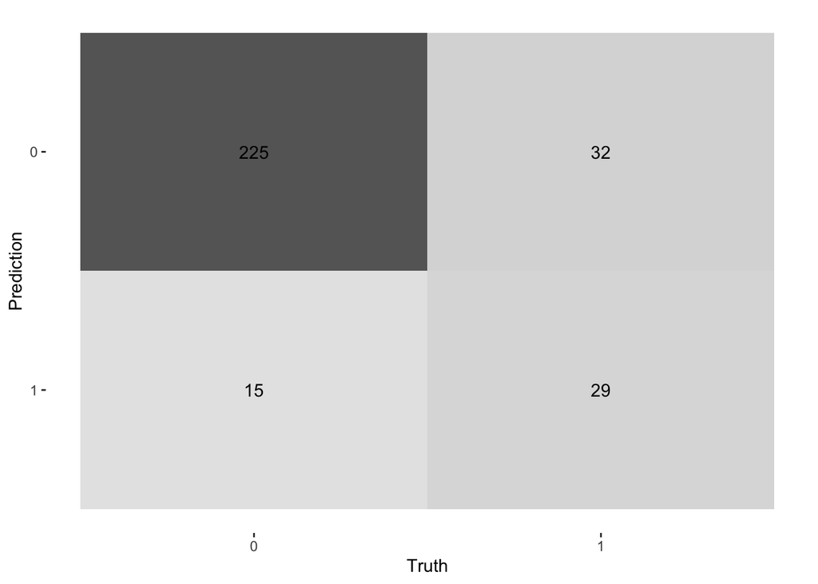

```r
eel_test_rs <- cbind(eel_test, final_eel_fit$.predictions)
eel_test_rs <- eel_test_rs[,-1]

cm<- eel_test_rs %>% yardstick::conf_mat(truth = Angaus, estimate = .pred_class)
autoplot(cm, type = "heatmap")
```

```r
tibble <- final_eel_fit %>% collect_metrics()
tibble
```

```
## # A tibble: 2 × 4
##   .metric  .estimator .estimate .config
##   <chr>    <chr>          <dbl> <chr>
## 1 accuracy binary         0.844 Preprocessor1_Model1
## 2 roc_auc  binary         0.866 Preprocessor1_Model1
```

```r
final_eel_accuracy <- tibble %>%
  filter(.metric == "accuracy") %>%
  pull(.estimate)

final_eel_auc <- tibble %>%
  filter(.metric == "roc_auc") %>%
  pull(.estimate)
```

2. How well did your model perform? What types of errors did it make?

```r
print(paste0("The model had an accuracy of ", round(final_eel_accuracy,2),
". The ROC area under the curve was ", round(final_eel_auc, 2), ". The rate of false negatives was ", round(cm$table[3]/nrow(eel_test), 2), ", and the rate of false positives was ", round(cm$table[2]/nrow(eel_test),2), "."))
```

```
## [1] "The model had an accuracy of 0.84. The ROC area under the curve was 0.87. The rate of false negatives was 0.11, and the rate of false positives was 0.05."
```

## Fit your model the evaluation data and compare performance

1. Now fit your final model to the big dataset: data/eval.data.csv

```r
# Read in eval data
eval_dat <- read_csv("eel.eval.data.csv") %>%
  rename(Angaus = Angaus_obs) %>% # rename to match previous data
  mutate(Angaus = as_factor(Angaus)) # make outcome a factor
prediction <- final_simple_fit %>% predict(new_data = eval_dat) # generate predictions
eval_dat_pred <- cbind(eval_dat, prediction)

# Compare predicted classes to actual classes
correct_predictions <- sum(eval_dat_pred$.pred_class == eval_dat_pred$Angaus)

# Calculate accuracy
accuracy <- correct_predictions / nrow(eval_dat_pred)

# Calculate auc
eval_dat_pred$pred_num <- as.numeric(eval_dat_pred$.pred_class)
auc <- auc(eval_dat_pred$Angaus, eval_dat_pred$pred_num)
```

2. How does your model perform on this data?

```r
print(paste0("The model had an accuracy of ", accuracy ," on these data, which isn't quite as good as the accuracy when applying the model to the testing data. However the difference is not too extreme and seems pretty good given that the dummy classifier would be 0.744. The model had an AUC of ", round(auc[1], 2), ". This does not seem great."))
```

[output not shown]

3. How do your results compare to those of Elith et al.?

```r
print(paste0("The model here does not do as well as the model in Elith et al. which found a model AUC of 0.858. My AUC of ", round(auc[1], 2) , " is fairly far off. I would guess that Elith et al. did more tuning to find the optimal values, where as I was more limited by computing power."))
```

```
## [1] "The model here does not do as well as the model in Elith et al. which found a model AUC of 0.858. My AUC of 0.66 is fairly far off. I would guess that Elith et al. did more tuning to find the optimal values, where as I was more limited by computing power."
```

- Use {vip} to compare variable importance

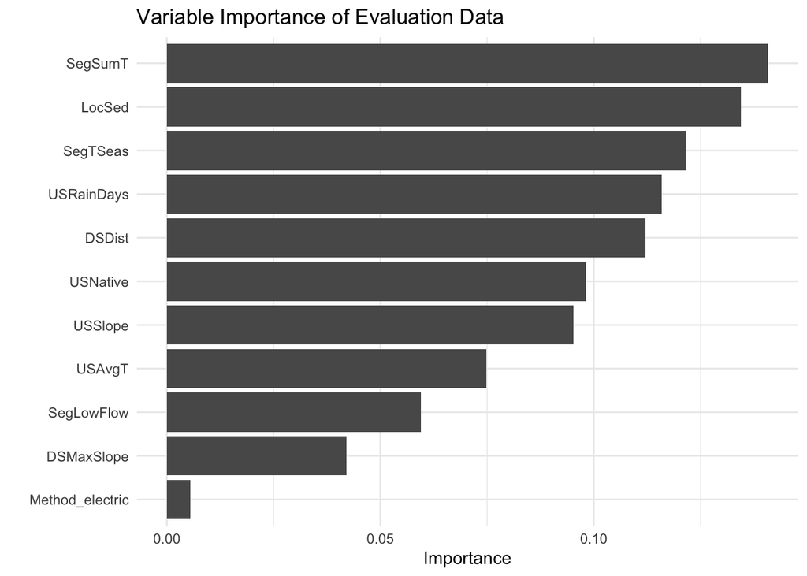

```r
set.seed(123)
orig_var_imp <- final_simple_fit %>%
  fit(data = eval_dat) %>%
  pull_workflow_fit() %>%
  vip(geom = "col", num_features = 16) +
  theme_minimal() +
  labs(title = "Variable Importance of Evaluation Data")
orig_var_imp
```

- What do your variable importance results tell you about the distribution of this eel species? **The variable importance results tell us that the distribution of this eel species in the environment is highly driven by summer air temperature, consistent with Elith et al. The distribution is less driven by fishing methods.**